# pyMez Tour

A tour of some of the features of pyMez

### Select The Topic of Interest

### Importing Topics

## Importing pyMez after you have installed it.

There are many ways to import pyMez, but to get the base api it is traditional to use

```
from pyMez import *
```

If a summary of the modules imported appears and a time taken to import them the variables in `pyMez/__init__.py`

```
VERBOSE_IMPORT=True
TIMED_IMPORT=True
```

are set to True. To remove this diagnostic output set these two variables to be False.

### Other ways

However, if a specific function or class is required then direct import also works (this form imports the full API)

```
from pyMez.Code.DataHandlers.XMLModels import XMLBase
```

If you want to have the import skip the API, then add the pyMez folder to sys.path and then import beginning with Code

```
import sys
sys.path.append(r"C:\ProgramData\Anaconda2\Lib\site-packages\pyMez")
from Code.DataHandlers.XMLModels import XMLBase
```

```python
# Here is the import statement for the base api. I have tried to include the most common things and exclude any slow loading
# modules.
from pyMez import *
```

```
Importing pyMez, this should take roughly 30 seconds
Importing Code.DataHandlers.GeneralModels
It took 0.448 s to import Code.DataHandlers.GeneralModels
Importing Code.DataHandlers.HTMLModels
It took 0.104 s to import Code.DataHandlers.HTMLModels
Importing Code.DataHandlers.NISTModels
It took 1.191 s to import Code.DataHandlers.NISTModels
Importing Code.DataHandlers.TouchstoneModels
It took 0.004 s to import Code.DataHandlers.TouchstoneModels
Importing Code.DataHandlers.XMLModels
It took 0.053 s to import Code.DataHandlers.XMLModels
Importing Code.DataHandlers.ZipModels
It took 0.004 s to import Code.DataHandlers.ZipModels
Importing Code.InstrumentControl.Experiments
It took 0.411 s to import Code.InstrumentControl.Experiments
Importing Code.InstrumentControl.Instruments
It took 0.033 s to import Code.InstrumentControl.Instruments
Importing Code.Utils.Names
It took 0.006 s to import Code.Utils.Names
It took 2.255 s to import all of the active modules
```

```python
# That is by far not all of the available modules. To get a listing of all of them print the constant API_MODULES
keys=sorted(API_MODULES.keys())
for key in keys:
    print("{0}:{1}".format(key,API_MODULES[key]))
```

```
Code.Analysis.Fitting:False
Code.Analysis.GeneralAnalysis:False
Code.Analysis.Interpolation:False
Code.Analysis.NISTUncertainty:False
Code.Analysis.Reports:False
Code.Analysis.SParameter:False
Code.Analysis.Transformations:False
Code.Analysis.Uncertainty:False
Code.DataHandlers.AbstractDjangoModels:False
Code.DataHandlers.GeneralModels:True
Code.DataHandlers.GraphModels:False
Code.DataHandlers.HTMLModels:True
Code.DataHandlers.MUFModels:False
Code.DataHandlers.NISTModels:True
Code.DataHandlers.RadiCALModels:False
Code.DataHandlers.StatistiCALModels:False
Code.DataHandlers.TouchstoneModels:True
Code.DataHandlers.Translations:False
Code.DataHandlers.XMLModels:True
Code.DataHandlers.ZipModels:True
Code.FrontEnds.AdvancedInterfaceFrame:False
Code.FrontEnds.BasicInterfaceFrame:False
Code.FrontEnds.EndOfDayDialog:False
Code.FrontEnds.GeneralInterfaceFrame:False
Code.FrontEnds.HTMLPanel:False
Code.FrontEnds.IEPanel:False
Code.FrontEnds.IPythonPanel:False
Code.FrontEnds.KeithleyIVPanel:False
Code.FrontEnds.MatplotlibWxPanel:False
Code.FrontEnds.ShellPanel:False
Code.FrontEnds.SimpleArbDBLowerInterfacePanel:False
Code.FrontEnds.SimpleLogLowerInterfacePanel:False
Code.FrontEnds.StyledTextCtrlPanel:False
Code.FrontEnds.VisaDialog:False
Code.FrontEnds.WxDialogFunctions:False
Code.FrontEnds.WxHTML2Panel:False
Code.FrontEnds.XMLEditPanel:False
Code.FrontEnds.XMLGeneral:False
Code.InstrumentControl.Experiments:True
Code.InstrumentControl.Instruments:True
Code.Utils.Alias:False
Code.Utils.DjangoUtils:False
Code.Utils.GetMetadata:False
Code.Utils.HPBasicUtils:False
Code.Utils.HelpUtils:False
Code.Utils.Names:True
Code.Utils.PerformanceUtils:False
Code.Utils.pyMezUnitTest:False
```

```python
# The other modules that I tend to use a lot but import slowly are
# Simple fits
from pyMez.Code.Analysis.Fitting import *
# Interpolation
from pyMez.Code.Analysis.Interpolation import *
# Scattering parameter analysis
from pyMez.Code.Analysis.SParameter import *
# Data transformations mostly for sparameters / waveparameters
from pyMez.Code.Analysis.Transformations import *
# Data translations
from pyMez.Code.DataHandlers.Translations import *
# The meta-data structures based on directional graphs
from pyMez.Code.DataHandlers.GraphModels import *
# The Statistical and MUF wrappers
from pyMez.Code.DataHandlers.MUFModels import *
from pyMez.Code.DataHandlers.StatistiCALModels import *
```

### Data Handling Topics

### DataHandling

There are many modules in the DataHandling subpackage. It is in the pyMez/Code/DataHandlers directory. The primary motivation of this subpackage is to create models for data manipulation and aggregation. The major data types of interest are ascii based tables, xml, html, touchstone files, and specialty models such as zip, statiscal, MUF. There are several major ideas:

1. The most important data type in science is a data table with a header (metadata) and content is more important than format.
2. XML and HTML is a very important way of reporting the data.
3. There is no perfect data format, so transformations between the formats are important

In the history of computers being available in science there has been countless formats for data and each has its own merits, the best format is the one that accomplishes its goals for the particular task.

## AsciiDataTable

For Ascii Tables we use the class `pyMez.Code.DataHandlers.GeneralModels.AsciiDataTable`

```python
# AsciiDataTable is a data type that means to be self documenting and handle common data that is small and non-uniform
# It has places for meta data and changing formatting
# to build it from scratch we can pass a options dictionary containing the data and column names and types
options={}
options["data"]=[[i+j for i in range(3)] for j in range(3) ]
options["column_types"]=["int","float","str"]
options["column_names"]=["a","b","c"]
options["header"]=["Data For Demonstatration","A 3x3 Matrix"]
options["footer"]=["Don't use footers they suck"]
options["metadata"]={"notes":"This is an example table"}
data_table=AsciiDataTable(**options)
```

```python
# now we can acess the text version as a string using print
print(data_table)
```

```
Data For Demonstatration
A 3x3 Matrix
a,b,c
0,1.0,2
1,2.0,3
2,3.0,4
Don't use footers they suck
```

```python
# we can save the data table and reopen it.
# the default location is the current working directory and an autonamed file
# it is in the atribute path
data_table.path
```

```
'Data_Table_20190124_001.txt'
```

```python
# now we have a meta data dictionary that follows the table around
data_table.metadata["notes"]
```

```
'This is an example table'
```

```python
# to saveas we just put the path we want into the save method
data_table.save(os.path.join(os.getcwd(),"pyMez_Tour_Files/test_data_table.txt"))
```

```python
# to open it again we can use the class and the path
reopen=AsciiDataTable(os.path.join(os.getcwd(),"pyMez_Tour_Files/test_data_table.txt"))
```

```python
print(reopen)
```

```
Data For Demonstatration
A 3x3 Matrix
a,b,c
0,1.0,2
1,2.0,3
2,3.0,4
Don't use footers they suck
```

```python
# The metadata dictionary is still there
reopen.metadata["notes"]
```

```
'This is an example table'
```

```python
# now we can format the file anyway we want
reopen.options["column_names_begin_token"]="!"
reopen.options["data_delimiter"]="\t"
reopen.options["comment_begin"]="!"
reopen.options["comment_end"]=""
reopen.options["header_line_types"]=["normal","comment"]

print(reopen)
```

```
Data For Demonstatration
!A 3x3 Matrix
!a,b,c
0	1.0	2
1	2.0	3
2	3.0	4
!Don't use footers they suck
```

```python
# I personally think footers are not the best idea so we can move the footer to the header
reopen.move_footer_to_header()
reopen.options["header_line_types"].append("comment")
print(reopen)
```

```
Data For Demonstatration
!A 3x3 Matrix
!Don't use footers they suck
!a,b,c
0	1.0	2
1	2.0	3
2	3.0	4
```

```python
# now we can save and reopen again
reopen.save("./pyMez_Tour_Files/Reopen.txt")
```

```python
rereopen=AsciiDataTable("./pyMez_Tour_Files/Reopen.txt")
```

```python
print(rereopen)
```

```
Data For Demonstatration
!A 3x3 Matrix
!Don't use footers they suck
!a,b,c
0	1.0	2
1	2.0	3
2	3.0	4
```

```python
# our metadata is still there becuase it is getting saved in the schema or reopen.options["metadata"]
rereopen.metadata
```

```
{'notes': 'This is an example table'}
```

```python
# it kind of works like a pandas data frame, but list is the fundamental data type and not a numpy array
reopen["a"]
```

```
[0, 1, 2]
```

```python
# this means when we add stuff it works like this
new_list=reopen["a"]+reopen["b"]+reopen["c"]
```

```python
print(new_list)
```

```
[0, 1, 2, 1.0, 2.0, 3.0, '2', '3', '4']
```

```python
# all the data is in the data attribute
rereopen.data
```

```
[[0, 1.0, '2'], [1, 2.0, '3'], [2, 3.0, '4']]
```

```python
# you can also get the data as a list of dictionaries
rereopen.get_data_dictionary_list()
```

```
[{'a': '0', 'b': '1.0', 'c': '2'},
 {'a': '1', 'b': '2.0', 'c': '3'},
 {'a': '2', 'b': '3.0', 'c': '4'}]
```

```python
# or get a row
rereopen.get_row(2)
```

```
[2, 3.0, '4']
```

```python
# or get a the unique values in a column
rereopen.get_unique_column_values("a")
```

```
[0, 1, 2]
```

```python
# there is the ability to use a row formatter
row_formatter="{0} Bannnas are {1:03.3f} but not {2}"
rereopen.options["row_formatter_string"]=row_formatter
print(rereopen)
```

```
Data For Demonstatration
!A 3x3 Matrix
!Don't use footers they suck
!a,b,c
0 Bannnas are 1.000 but not 2
1 Bannnas are 2.000 but not 3
2 Bannnas are 3.000 but not 4
```

```python
# now to make a you own class inherit from AsciiDataTable and add special methods
class NewDataClass(AsciiDataTable):
    """Same as an ascii data but plots the first column using .show()"""
    def show(self):
        plt.plot(self.get_column(column_index=0))
        plt.show()
```

```python
new_data=NewDataClass(os.path.join(os.getcwd(),"pyMez_Tour_Files/test_data_table.txt"))
```

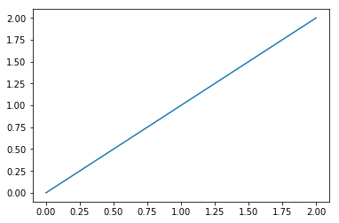

```python
new_data.show()
```

```python
# If you do data analysis using pandas we can transform the AsciiDataTable to a pandas data frame, or if
# want to preserve the header a dictionary of pandas data frames
from pyMez.Code.DataHandlers.Translations import *
pandas_df=AsciiDataTable_to_DataFrame(data_table)
pandas_dictionary=AsciiDataTable_to_DataFrameDictionary(data_table)
```

```python
pandas_df
```

|  | a | b | c |
| --- | --- | --- | --- |
| 0 | 0 | 1.0 | 2 |
| 1 | 1 | 2.0 | 3 |
| 2 | 2 | 3.0 | 4 |

```python
pandas_dictionary["Data"]
```

|  | a | b | c |
| --- | --- | --- | --- |
| 0 | 0 | 1.0 | 2 |
| 1 | 1 | 2.0 | 3 |
| 2 | 2 | 3.0 | 4 |

```python
pandas_dictionary["Header"]
```

|  | Header_Line_Content |
| --- | --- |
| 0 | Data For Demonstatration |
| 1 | A 3x3 Matrix |

```python
pandas_dictionary["Footer"]
```

|  | Footer_Line_Content |
| --- | --- |
| 0 | Don't use footers they suck |

## Touchstone Models

```python
s1p=S1PV1("./pyMez_Tour_Files/load.s1p")
s2p=S2PV1("./pyMez_Tour_Files/thru.s2p")
s4p=SNP("./pyMez_Tour_Files/Solution_0.s4p")
```

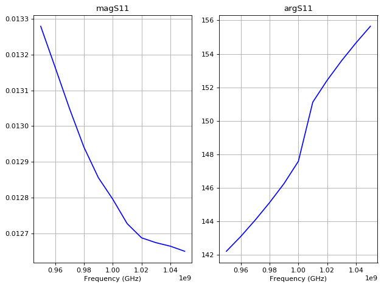

```python
# now the touchstone family has a format ("RI","MA","DB")
# the class has a very similar interface as the AsciiDataTable
# Except all have a show method that plots the data
s1p.show();
```

```python
s1p.column_names
```

```
['Frequency', 'reS11', 'imS11']
```

```python
s1p["reS11"]
```

```
[-0.01049680327,
 -0.01052926564,
 -0.01056833871,
 -0.01061750133,
 -0.01069049455,
 -0.01080291858,
 -0.01114448419,
 -0.01124639209,
 -0.01135111716,
 -0.01144485541,
 -0.01152392736]
```

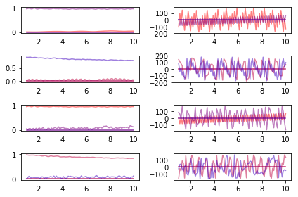

```python
# because of the number of many port parameters they get clustered
s4p.show(display_legend=False);
```

```python
# There are two attributes that contain the sparamters, one is .data that has it in tabular form
# the other is .sparamter_complex that stores it in complex numbers
print(s1p.sparameter_complex)
print(s1p.data)
```

```
[[950000000.0, (-0.01049680327+0.008134703699j)], [960000000.0, (-0.01052926564+0.00790323825j)], [970000000.0, (-0.01056833871+0.007654562961j)], [980000000.0, (-0.01061750133+0.007398920957j)], [990000000.0, (-0.01069049455+0.007140403558j)], [1000000000.0, (-0.01080291858+0.006857244594j)], [1010…
[[950000000.0, -0.01049680327, 0.008134703699], [960000000.0, -0.01052926564, 0.00790323825], [970000000.0, -0.01056833871, 0.007654562961], [980000000.0, -0.01061750133, 0.007398920957], [990000000.0, -0.01069049455, 0.007140403558], [1000000000.0, -0.01080291858, 0.006857244594], [1010000000.0, -0…
```

```python
#  to change the data format use
s1p.change_data_format("MA")
print(s1p)
```

```
# GHz S MA R 50
950000000  0.0132799203  142.225403
960000000  0.01316535642  143.1082064
970000000  0.01304921903  144.0844872
980000000  0.01294122737  145.1288695
990000000  0.01285581723  146.2602148
1000000000  0.01279550129  147.5943138
1010000000  0.01272691252  151.1235182
1020000000  0.01268709119  152.4297108
1030000000  0.01267346255  153.5933685
1040000000  0.01266360453  154.6567499
1050000000  0.01264932592  155.6482117
```

```python
s1p.change_data_format("RI")
print(s1p)
```

```
# GHz S RI R 50
950000000  -0.01049680327  0.008134703699
960000000  -0.01052926564  0.00790323825
970000000  -0.01056833871  0.007654562961
980000000  -0.01061750133  0.007398920957
990000000  -0.01069049455  0.007140403558
1000000000  -0.01080291858  0.006857244594
1010000000  -0.01114448419  0.006146118651
1020000000  -0.01124639209  0.005872048007
1030000000  -0.01135111716  0.005636381121
1040000000  -0.01144485541  0.005420531738
1050000000  -0.01152392736  0.005215797579
```

## XML and HTML Models

XML and HTML are markup languages used extensively on the web. We use them for reporting and data storage. The modules `pyMez.Code.DataHandlers.XMLModels` and `pyMez.Code.DataHandlers.HTMLModels` have most of these models, they are loaded in the base API. However two analysis modules `pyMez.Code.Analysis.Reports` and `pyMez.Code.Analysis.ProgramAnalysis` contain related classes and functions. The folder pyMez/Code/DataHandlers/XSL has all of the style sheets.

```python
# A simple xml log
xml_log=XMLLog()
```

```python
# it can add an entry
xml_log.add_entry("This is an entry")
print(xml_log)
```

```
<Log><Entry Date="2019-01-25T00:43:00.230000" Index="1">This is an entry</Entry></Log>
```

```python
xml_log.save("./pyMez_Tour_Files/log.xml")
```

```python
xml_reopen_log=XMLLog("./pyMez_Tour_Files/log.xml")
```

```python
print(xml_reopen_log)
```

```
<Log><Entry Date="2019-01-25T00:43:00.230000" Index="1">This is an entry</Entry></Log>
```

```python
# This an xml data table created from the AsciiDataTable
xml_data_table=AsciiDataTable_to_XmlDataTable(data_table)
```

```python
print(xml_data_table)
```

```
<Data_Table><Data_Description><notes>This is an example table</notes></Data_Description><Data><Tuple a="0" b="1.0" c="2"/><Tuple a="1" b="2.0" c="3"/><Tuple a="2" b="3.0" c="4"/></Data></Data_Table>
```

```python
# now we can change this to html using a XSL
html_data_table=xml_data_table.to_HTML(os.path.join(TESTS_DIRECTORY,"../XSL/DEFAULT_MEASUREMENT_STYLE.xsl"))
```

```python
print(html_data_table)
```

```
<!DOCTYPE html PUBLIC "-//W3C//DTD HTML 4.0 Transitional//EN" "http://www.w3.org/TR/REC-html40/loose.dtd">
<h3>Data Description:</h3><table><tr>
<td><b>notes :</b></td>
<td>This is an example table</td>
</tr></table><h3>Data:</h3><table border="2" bgcolor="white" cellpadding="1" bordercolor="black" bordercolorlight="black">
<tr>
<th bgcolor="silver"><b>a</b></th>
<th bgcolor="silver"><b>b</b></th>
<th bgcolor="silver"><b>c</b></th>
</tr>
<tr>
<td>0</td>
<td>1.0</td>
<td>2</td>
</tr>
<tr>
<td>1</td>
<td>2.0</td>
<td>3</td>
</tr>
<tr>
<td>2</td>
<td>3.0</td>
<td>4</td>
</tr>
</table>
```

```python
# if we want to store it we can use save_HTML or load it into the HTMLBase class
html_data_table_2=HTMLBase(html_text=html_data_table)
```

```python
html_data_table_2.show()
```

```
file://c:/users/sandersa/appdata/local/temp/1/tmpxo3sog.html
```

```python
# or for a more interactive example, we can use a translation from s2p to xml and then to html and show it
xml_s2p=S2PV1_to_XmlDataTable(s2p,format="MA")
html_s2p=HTMLBase(html_text=xml_s2p.to_HTML(os.path.join(TESTS_DIRECTORY,"../XSL/S2P_MA_STYLE.xsl")))
html_s2p.show()
```

```
file://c:/users/sandersa/appdata/local/temp/1/tmptssjuj.html
```

```python
# the HTMLReport Class is a descendant of HTMLBase but has the added ability to embed images
from pyMez.Code.Analysis.Reports import HTMLReport
```

```python
html_report=HTMLReport(None,html_text=html_data_table)
```

```python
# now we want to add the image to the report
html_report.embedd_image_figure(image=s2p.show(silent=True),image_mode="MatplotlibFigure",
                                caption="A Plot of Table Data",figure_id="Figure1")
html_report.show()
```

```
file://c:/users/sandersa/appdata/local/temp/1/tmpynztgz.html
```

```python
help(html_report.embedd_image_figure)
```

```
Help on method embedd_image_figure in module pyMez.Code.Analysis.Reports:

embedd_image_figure(self, image, image_mode='MatplotlibFigure', figure_id='image', caption='', style='', **options) method of pyMez.Code.Analysis.Reports.HTMLReport instance
    Embedds an image in the report. image_mode can be  MatplotlibFigure (a reference to the figure class),
    Image (the PIL class),
    Base64 (a string of the values),
    Png, Jpg, Bmp Tiff(the file name),
    or a Ndarray of the image values. The image is in a <figure id=figure_id> tag
```

```python
# we can also add elements one by one
html_report.append_to_body("<h1>Title</h1>")
```

```python
html_report.show()
```

```
file://c:/users/sandersa/appdata/local/temp/1/tmpojfnpn.html
```

```python
# or add a log
html_log=HTMLBase(html_text=xml_log.to_HTML(os.path.join(TESTS_DIRECTORY,"../XSL/DEFAULT_LOG_STYLE.xsl")))
html_report+html_log
html_report.show()
```

```
file://c:/users/sandersa/appdata/local/temp/1/tmpg6rtt0.html
```

## Meta Models

Meta Models are based on a series of translations found in `pyMez.Code.DataHandlers.Translations` and the models are in `pyMez.Code.DataHandlers.GraphModels`. They are meant to be integrated into a Universal Data Translator.

```python
# the modules are not loaded in the Base Api
from pyMez.Code.DataHandlers.GraphModels import *
```

```python
# the meta models I use the most are TableGraph, MetadataGraph and ImageGraph
image_graph=ImageGraph()
```

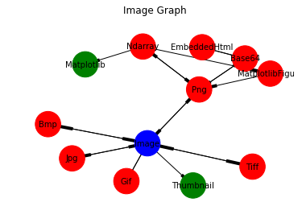

```python
%matplotlib inline
# for a visualization of the formats avaible to the meta model use the show attribute
# The green nodes are a one way path, use jump_to_external_node to reach them. The state of the graph will
# then be left in the closest node. The blue node is the current node
plt.close()
image_graph.show()
```

```python
# The PIL Image class has a show method
image_pil=image_graph.data
image_pil.show()
```

```python
%matplotlib wx
# This means that we can take data in any of these formats and turn it into any of the others
image_graph.move_to_node("MatplotlibFigure")
figure=image_graph.data
figure.show()
```

```
pil_image.mode is RGB
```

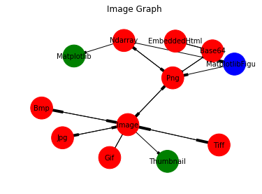

```python
%matplotlib inline
# now the graph is at a different node
image_graph.show()
```

```python
metadata_graph=MetadataGraph()
```

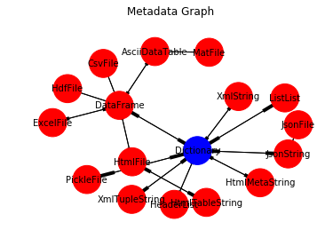

```python
%matplotlib inline
metadata_graph.show()
```

```python
# metadata is taken to be any key value pair. The most natural way to express this in python is a dictionary
metadata_dictionary={"Device":"42","Time":datetime.datetime.now(),"Notes":"A Test of metadata"}
metadata_graph.set_state(node_name="Dictionary",node_data=metadata_dictionary)
```

```python
# now we can express this in any format in the graph
# for example we move to the AsciiDataTable node and print it
metadata_graph.move_to_node("AsciiDataTable")
meta_table=metadata_graph.data
print(meta_table)
```

```
Property,Value
Device,42
Notes,A Test of metadata
Time,2019-01-24 17:43:13.405000
```

```python
# or in a pandas data frame
metadata_graph.move_to_node("DataFrame")
meta_df=metadata_graph.data
print(meta_df)
```

```
  Property                       Value
0   Device                          42
1    Notes          A Test of metadata
2     Time  2019-01-24 17:43:13.405000
```

```python
# or in as html meta data
metadata_graph.move_to_node("HtmlMetaString")
meta_df=metadata_graph.data
print(meta_df)
```

```
<meta name="Device" content="42" />
<meta name="Notes" content="A Test of metadata" />
<meta name="Time" content="2019-01-24 17:43:13.405000" />
```

```python
# or as a header list
metadata_graph.move_to_node("HeaderList")
meta_df=metadata_graph.data
print(meta_df)
```

```
['Device=42', 'Notes=A Test of metadata', 'Time=2019-01-24 17:43:13.405000']
```

```python
# or as xml fragment
metadata_graph.move_to_node("XmlString")
meta_df=metadata_graph.data
print(meta_df)
```

```
<Device>42</Device>
<Notes>A Test of metadata</Notes>
<Time>2019-01-24 17:43:13.405000</Time>
```

```python
# or as json
metadata_graph.move_to_node("JsonString")
meta_df=metadata_graph.data
print(meta_df)
```

```
{"Device": "42", "Notes": "A Test of metadata", "Time": "2019-01-24 17:43:13.405000"}
```

```python
table_graph=TableGraph()
```

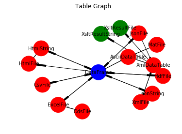

```python
table_graph.show()
```

### Analysis Topics

## Overview Analysis

The Analysis subpackage contains modules dedicated to the most common analysis tasks. It has an elaborate module for scattering parameters and more basic functionality for fits and other common tasks such as comparing tables with uncertainties.

## Fitting and Interpolation

The fitting and interpolation modules allow for the creation of and manipulation of data.They are not in the base API and must be loaded separately. Fitting for functions of a single variable works using a sympy/scipy composite function.

```python
from pyMez.Code.Analysis.Fitting import *
from pyMez.Code.Analysis.Interpolation import *
```

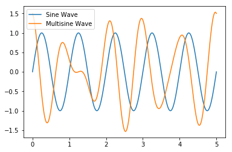

```python
# Now say we want to create a table of data
time_list=np.linspace(0,5,1000)
sine_wave=FunctionalModel(variables=["t"],parameters=["A","phi"],equation="A*sin(2*pi*t+phi)")
f_list=[1,1.2,1.4]
multisine=Multicosine(f_list)
# Now we have some fucntions we can set the parameters and use them to plot
sine_wave.set_parameters({"A":1.0,"phi":0})
multisine.set_parameters({"A_1":1.,"A_2":.3,"A_3":.5,"phi_1":0,"phi_2":np.pi/2.,"phi_3":0})
plt.plot(time_list,sine_wave(time_list),label="Sine Wave")
plt.plot(time_list,multisine(time_list),label="Multisine Wave")
plt.legend()
plt.show()
```

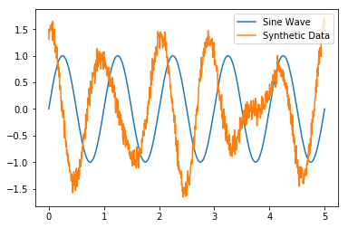

```python
# If we want synthetic data we can use a data simulator or just add random noise
sythetic_data=DataSimulator(model=multisine,output_noise_center=0.,output_noise_width=.1,output_noise_type="normal")
sythetic_data.set_parameters({"A_1":1.,"A_2":.3,"A_3":.5,"phi_1":0,"phi_2":np.pi/2.,"phi_3":0})
sythetic_data.set_x(0,5,1000)
sythetic_data.get_data()
plt.close()
plt.plot(time_list,sine_wave(time_list),label="Sine Wave")
plt.plot(time_list,sythetic_data.data,label="Synthetic Data")
plt.legend()
plt.show()
```

```python
# now we can use the multisine to fit the synthetic data
multisine.fit_data(time_list,sythetic_data.data)
# the fit method just sets the parameter values to the least squares value
```

```python
multisine.parameter_values
```

```
{'A_1': 0.999681011282954,
 'A_2': 0.30027002738120456,
 'A_3': 0.49759480647792703,
 'phi_1': 0.0029180858341852287,
 'phi_2': -1.5570041333652083,
 'phi_3': 0.01296227270060869}
```

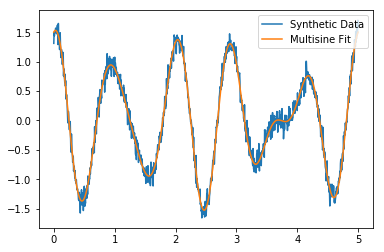

```python
plt.close()
plt.plot(time_list,sythetic_data.data,label="Synthetic Data")
plt.plot(time_list,multisine(time_list),label="Multisine Fit ")
plt.legend()
plt.show()
```

```python
# now say we want to build a table with the data
# we start with a table that just has the time column
new_table=AsciiDataTable(None,column_types=["float"],column_names=["Time"],data=map(lambda x: [x],time_list.tolist()))
```

```python
# we can add columns
new_table.add_column(column_name="Sine_Model",column_data=sine_wave(time_list).tolist(),column_type="float")
```

```python
# ideal data
multisine.set_parameters({"A_1":1.,"A_2":.3,"A_3":.5,"phi_1":0,"phi_2":np.pi/2.,"phi_3":0})
new_table.add_column(column_name="Multisine_Model",column_data=multisine(time_list).tolist(),column_type="float")
# data with noise
new_table.add_column(column_name="Synthetic_Data",column_data=sythetic_data.data.tolist(),column_type="float")
#fit of data with noise
multisine.fit_data(time_list,sythetic_data.data)
new_table.add_column(column_name="Synthetic_Fit",column_data=multisine(time_list).tolist(),column_type="float")
```

```python
# now we have built the table with
new_table.column_names
```

```
['Time', 'Sine_Model', 'Multisine_Model', 'Synthetic_Data', 'Synthetic_Fit']
```

```python
new_table.save("./pyMez_Tour_Files/Fitting_Table.txt")
```

```python
help(interpolate_table)
```

```
Help on function interpolate_table in module pyMez.Code.Analysis.Interpolation:

interpolate_table(table, independent_variable_list)
    Returns a copy of the table interpolated to the independent variable list
    Assumes there is a single independent variable in the first column
```

```python
# now if we want to interpolate we can just use interpolate_table
new_time_list=np.linspace(1,2,1000).tolist()
interpolated_new_table=interpolate_table(new_table,new_time_list)
```

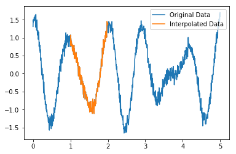

```python
plt.plot(time_list,sythetic_data.data,label="Original Data")
plt.plot(interpolated_new_table["Time"],interpolated_new_table["Synthetic_Data"],label="Interpolated Data")
plt.legend()
plt.show()
```

## Uncertainty

In the Analysis subpackage there are classes and functions to create and compare uncertainties. They are contained in `pyMez.Code.Analysis.Uncertainty`, `pyMez.Code.Analysis.SParameter`, and `pyMez.Code.Analysis.NISTUncertainty`. In addition, there are several data types in the DataHandlers subpackage that deal with the output of error calculators such as StatistiCAL, and the Microwave Uncertainty Framework.

```python
# these modules are not in the Base API so you need to load them separately.
from pyMez.Code.Analysis.Uncertainty import *
from pyMez.Code.Analysis.SParameter import *
```

```python
# Now if you have two tables at least one with uncertainty we can create a standard error table
help(standard_error_data_table)
```

```
Help on function standard_error_data_table in module pyMez.Code.Analysis.Uncertainty:

standard_error_data_table(table_1, table_2, **options)
    standard error data table takes two tables and creates a table that is the standard error of the two tables,
    at least one table must have uncertainties associated with it. The input tables are assumed to have data
    in the form [[x, y1, y2,...]..] Uncertainties can be specified as a column name in the respective
    table, fractional, constant, or a function of the values. The returned table is an object
    of the class StandardErrorModel(AsciiDataTable) that has data in the form
    [[independent_varaible,SEValue1,SEValue2...]...] where column names are formed by
    appending SE to the value column names. To plot the table use result.show()
```

```python
# The standard error table has a lot of possibilities, any set of column names can be used as the values
# and the errors can be a function, a percentage, a constant or a table. In addition, the error for table 2 can be specified
# or unspecified. In addtion the resulting table only has values at the independent_variable locations for table_1
# as an example we can take a raw file scattering parameter measurement from cal services, calculate the uncertainty using
# the calrep program, and then compare it to a results file
raw_scattering_parameters=TwoPortRawModel("./pyMez_Tour_Files/CTN206.A35_092805")
raw_scattering_parameters.column_names
```

```
['Frequency',
 'Direction',
 'Connect',
 'magS11',
 'argS11',
 'magS21',
 'argS21',
 'magS22',
 'argS22']
```

```python
# Now we can estimate the errors using the calrep program. It creates a series error estimates based on
# the six port error analysis
calrep_scattering_parameters=calrep(raw_scattering_parameters)
calrep_scattering_parameters.column_names
```

```
['Frequency',
 'magS11',
 'uMbS11',
 'uMaS11',
 'uMdS11',
 'uMgS11',
 'argS11',
 'uAbS11',
 'uAaS11',
 'uAdS11',
 'uAgS11',
 'magS21',
 'uMbS21',
 'uMaS21',
 'uMdS21',
 'uMgS21',
 'argS21',
 'uAbS21',
 'uAaS21',
 'uAdS21',
 'uAgS21',
 'magS22',
 'uMbS22',
 'uMaS22',
 'uMdS22',
 'uMgS22',
 'argS22',
 'uAbS22',
 'uAaS22',
 'uAdS22',
 'uAgS22']
```

```python
# Now we can load a file that was created as a mean of good measurements
mean_scattering_parameters=ResultFileModel("./pyMez_Tour_Files/CTN206.Results")
mean_scattering_parameters.column_names
```

```
['Device_Id',
 'Frequency',
 'Number_Measurements',
 'magS11',
 'argS11',
 'magS21',
 'argS21',
 'magS22',
 'argS22']
```

```python
# now we can specify all of the options. The standard error data table can handle any two AsciiDataTable descendants
error_options={"independent_variable_column_name":"Frequency",
              "value_column_names":['magS11','argS11','magS21',
                                            'argS21','magS22','argS22'],
              "table_1_uncertainty_column_names":['uMgS11','uAgS11',
                                                  'uMgS21','uAgS21','uMgS22','uAgS22'],
              "table_2_uncertainty_column_names":['uMgS11','uAgS11',
                                                  'uMgS21','uAgS21','uMgS22','uAgS22'],
               "uncertainty_table_1":None,
               "uncertainty_table_2":None,
               "uncertainty_function_table_1":None,
               "uncertainty_function_table_2":None,
               "uncertainty_function":None,
               "uncertainty_type":None,
               "table_1_uncertainty_type":"table",
               "table_2_uncertainty_type":None,
               "expansion_factor":1,
               'debug':False}
standard_error_scattering_parameters=standard_error_data_table(calrep_scattering_parameters,
                                                               mean_scattering_parameters,**error_options)
```

```python
# now we can save, plot and use the standard error table
standard_error_scattering_parameters.column_names
```

```
['Frequency',
 'SEmagS11',
 'SEargS11',
 'SEmagS21',
 'SEargS21',
 'SEmagS22',
 'SEargS22']
```

```python
standard_error_scattering_parameters.save("./pyMez_Tour_Files/Standard_Error.txt")
```

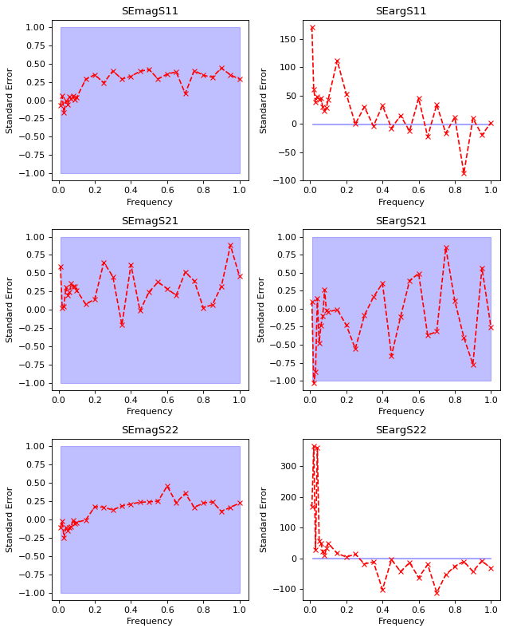

```python
standard_error_scattering_parameters.show();
```

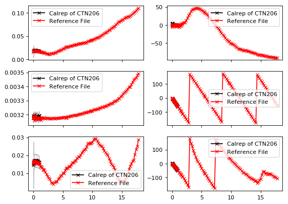

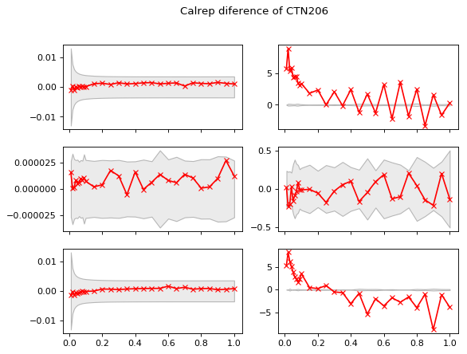

```python
# we can use a special function to look at the calrep and results comparison
plot_calrep_results_comparison(calrep_model=calrep_scattering_parameters,results_model=mean_scattering_parameters);
plot_calrep_results_difference_comparison(calrep_model=calrep_scattering_parameters,results_model=mean_scattering_parameters);
```

## Scattering Parameters

There are many functions based on the manipulation of scattering parameter and wave parameter data normally taken using a vector network analyzer. The functions and classes that deal with scattering parameters reside in several modules. In the base API there is `pyMez.Code.DataHandlers.TouchstoneModels` for dealing with snp style files. The add on modules `pyMez.Code.DataHandlers.StatistiCALModels` and `pyMez.Code.DataHandlers.MUFModels` have classes and functions that interact with vna calibration software from NIST. The modules `pyMez.Code.DataHandlers.Translations` and `pyMez.Code.Analysis.Transformations` have conversion functions to transform scattering parameters to other data types and wave parameters to scattering parameters. Finally the module `pyMez.Code.Analysis.SParameters` has functions for analyzing frequency dependent data, calculating uncertainties, applying corrections and plotting.

```python
# Lets open three connects (measurements) of a single device
connect_1=SNP(r"./pyMez_Tour_Files/Line_4909_WR15_20180313_001.s2p")
connect_2=SNP(r"./pyMez_Tour_Files/Line_4909_WR15_20180313_002.s2p")
connect_3=SNP(r"./pyMez_Tour_Files/Line_4909_WR15_20180313_003.s2p")
```

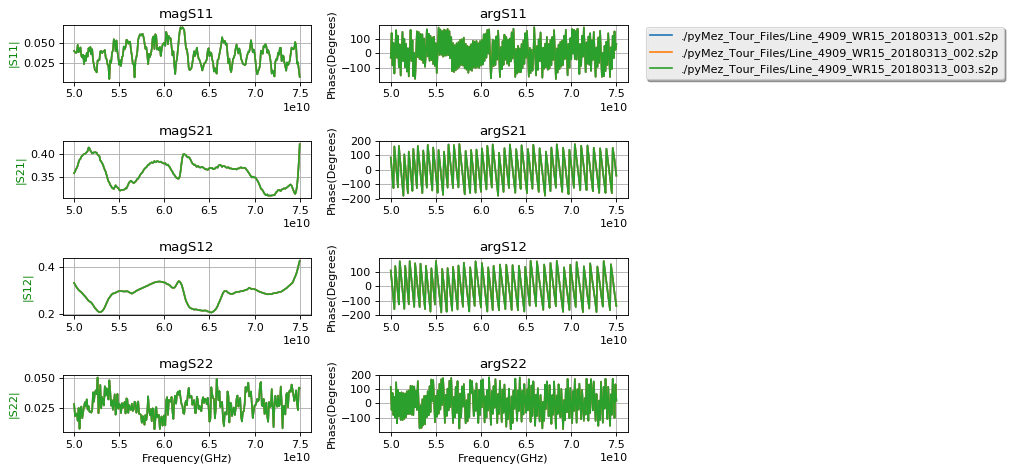

```python
# now if we want to plot them together we can use
compare_s2p_plots([connect_1,connect_2,connect_3]);
```

```python
# we can calculate the mean of the three in multiple ways. If we convert to AsciiDataTables we can add the files
# and then use frequency_model_collapse_multiple_measurements
first_file=Snp_to_AsciiDataTable(connect_1)
joined_data_table=first_file.copy()
for connect in [connect_2,connect_2]:
    joined_data_table=joined_data_table+Snp_to_AsciiDataTable(connect)
mean_table=frequency_model_collapse_multiple_measurements(joined_data_table)
std_table=frequency_model_collapse_multiple_measurements(joined_data_table,method="STD")
```

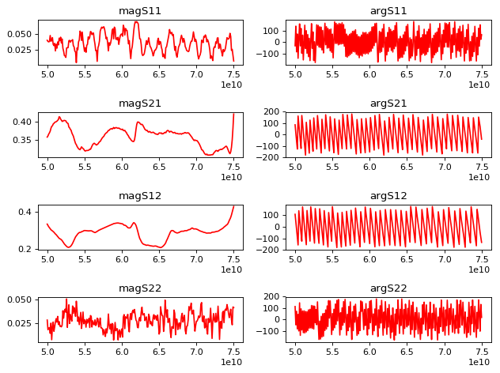

```python
# now we can plot the tables using the general function plot_frequency_model
plot_frequency_model(mean_table,plot_format="r-");
```

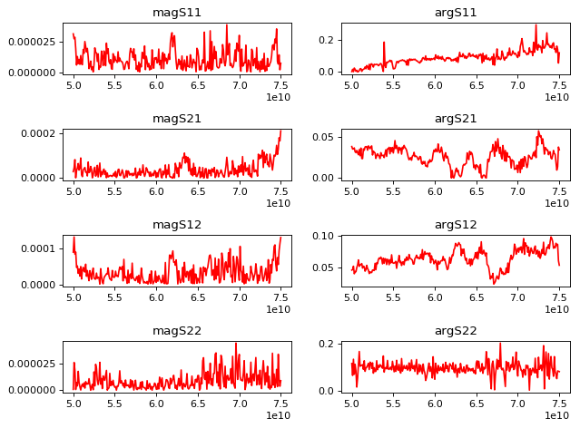

```python
plot_frequency_model(std_table,plot_format="r-");
```

```python
# we can also correct the data given a sixteen term correction in s4p format
correction=SNP("./pyMez_Tour_Files/Solution_WR15.s4p")
```

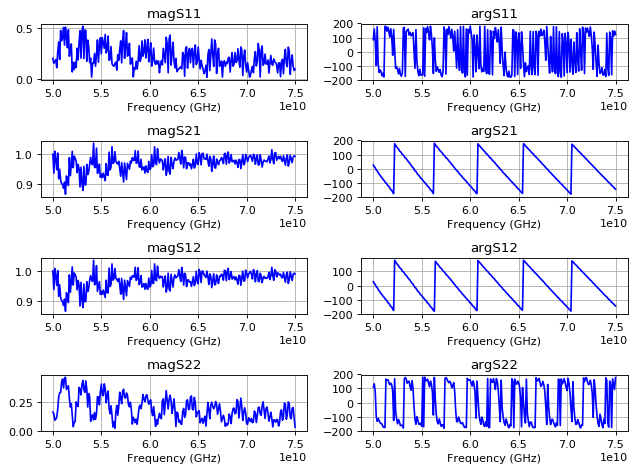

```python
# The correction is made to the complex data so that it is essentially format free (just a list of lists of complex numbers)
corrected_complex_data=correct_sparameters_sixteen_term(sixteen_term_correction=correction.sparameter_complex,
                                                        sparameters_complex=connect_1.sparameter_complex)
# we can use the S2PV1 model to encapsulate the data
corrected_connect_1=S2PV1(sparameter_complex=corrected_complex_data)
corrected_connect_1.show();
```

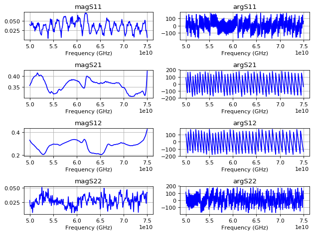

```python
# to check we can uncorrect the s2p

uncorrected_complex_data=uncorrect_sparameters_sixteen_term(sixteen_term_correction=correction.sparameter_complex,
                                                        sparameters_complex=corrected_connect_1.sparameter_complex)
# we can use the S2PV1 model to encapsulate the data
uncorrected_connect_1=S2PV1(sparameter_complex=uncorrected_complex_data,column_types=["float" for i in range(9)])
uncorrected_connect_1.show();
```

## Other Analysis

pyMez has several other analytic modules and will be extended with time. For instance `pyMez.Code.Analysis.ProgramAnalysis` provides tools for creating an SVG example of a function that links a text form of input, a copy of the code, and a form of the output to an SVG diagram.

### Instrument Control Topics

## Overview

Instrument Control in pyMez is primarily contained in the module `pyMez.Code.InstrumentControl.Instruments`. The subpackage `pyMez.Code.InstrumentControl` is meant to expand overtime, as more instrument drivers are added. The module `pyMez.Code.InstrumentControl.Experiments` houses the combination of several instruments and data management. If an experiment makes it to the place that it is going to be replicated several times, then the experiment class can be bound to a GUI.

### Behavior of Instruments

There are a few issues that the package pyvisa did not address adequately for our lab. The Instrument class (VisaInstrument) now has several capabilities:

1. The ability to link to a static data document in xml that describes the instrument (InstrumentSheet)
2. The ability to save the state of the instrument with a flexible number of state commands included.(InstrumentState)
3. The ability to load that state at a later time.
4. A diagnostic mode (emulation_mode) that allows for prototyping even when an instrument or bus is not present

### Basics of the Instruments module

For the most part we deal with instruments using VISA (Using the class VisaInstrument). The main interface has some common features

## Instrument Sheets

To provide information regarding an instrument, including the default state commands, we have developed instrument sheets. Essentially they are xml documents that provide a series of information. The instrument sheet data handler class lives in `pyMez.Code.DataHandlers.XMLModels` and is a parent of the VisaInstrument class. If a call to an instrument does not return an instrument from the instrument_description_directory passed in creation of the class it behaves as if the description is empty. The creation of VisaInstrument looks for any unique string that identifies the instrument and then deduces the gpib address from the instrument sheet. The sheet can be extended to include any information that the user needs or wants.

An Example Instrument Sheet

```
<?xml version="1.0" encoding="utf-8"?>
<?xml-stylesheet type="text/xsl" href="DEFAULT_INSTRUMENT_STYLE.xsl"?>
<!-- Written by Aric Sanders 04/2017 -->


<Instrument>
<!-- Information Specific To My Power Meter-->
    <Specific_Information>
        <Name>NRPPowerMeter</Name>
        <Alias>RS_NRP_Power_Meter_4639_01</Alias>
        <Location>Building 1, 4639</Location>
        <Manual href="../Documentation/Manuals/RS_NRP2_Manual.pdf"/>
        <Image href="./RS_NRP_Power_Meter_4639_01_Images/NRP.jpg"/>
        <Price></Price>
        <Serial></Serial>
        <IDN>Rohde&amp;Schwarz,NRP,102508,06.01</IDN>
        <Instrument_Type>GPIB</Instrument_Type>
        <Instrument_Address>GPIB::14</Instrument_Address>
        <Purchase_Date></Purchase_Date>
        <NIST_Tag>935166</NIST_Tag>
    </Specific_Information>
<!-- Information Common To All NRP Power meters-->
    <General_Information>
    <Manufacturer>Rohde and Schwarz</Manufacturer>
    <Manufacturer_Website href="https://www.rohde-schwarz.com/us/home_48230.html" />
     <Commands_Description>
        <Command>This is the command sent over the GPIB bus.</Command>
        <Type>Whether or not it returns a value or just sets something.</Type>
        <Argument>The parameter the command passes to the instrument. Optional parameters
        are denoted with an *. The types of paramters are int=integer, float=floating point number,
        string=string, and None=NULL.</Argument>
        <Returns> What gets returned by the function. </Returns>
        <Description>A one line describing the purpose of the function, for more detailed info look in the manual. </Description>
    </Commands_Description>
    <Commands>

    </Commands>
    <Command_Parameter_Definitions>

    </Command_Parameter_Definitions>
    <State_Commands>
        <Tuple Set="SENS:FUNC" Query="SENS:FUNC?"/>
        <Tuple Set="UNIT:POW" Query="UNIT:POW?"/>
    </State_Commands>
    </General_Information>

</Instrument>
```

```python
# for instance the NRPPowerMeter is a Rohde and Schwartz power meter
power_meter=VisaInstrument("NRPPowerMeter")
```

```
Unable to load resource entering emulation mode ...
```

```python
# Since the address was a unique string in the xml data sheet it finds all the information in that sheet and loads it
# into attributes that mirror the tag names (all lower case)
power_meter.idn
```

```
'Rohde&Schwarz,NRP,102508,06.01'
```

```python
# this lets the user define information that is domain or user specific that is added to the control class on creation
power_meter.nist_tag
```

```
'935166'
```

```python
# it also allows the user to define "State_Commands" in the general description that creates a
# default state query dictionary constant for the instrument, this can be changed after creation
power_meter.DEFAULT_STATE_QUERY_DICTIONARY
```

```
{'SENS:FUNC': 'SENS:FUNC?', 'UNIT:POW': 'UNIT:POW?'}
```

```python
# this controls the behaivor of the .get_state and save_state method when called without a state dictionary or table
power_meter.get_state()
```

```
{'SENS:FUNC': 'Buffer Read at 2019-01-25T00:43:26.697000',
 'UNIT:POW': 'Buffer Read at 2019-01-25T00:43:26.696000'}
```

```python
# In addition the instrument_sheet has a XSL that transforms it to html
html_instrument_sheet=HTMLBase(html_text=power_meter.to_HTML(os.path.join(TESTS_DIRECTORY,"../XSL/DEFAULT_INSTRUMENT_STYLE.xsl")))
html_instrument_sheet.show()
```

```
file://c:/users/sandersa/appdata/local/temp/1/tmp84mlat.html
```

## Instrument States

A major thrust of pyMez is to provide dynamic metadata for instruments, that is the ability to store the state of an instrument at a given moment in a tabular or xml form and then recall it. For the xml version of states we use classes found in `pyMez.Code.DataHandlers.XMLModels` which is part of the Base API. This is the default style, however it is easy to convert to a regular AsciiDataTable or similar. When dealing with states it is important to realize that a state dictionary without an index will be written to the instrument in random order, if order is important a state table with an index is available. The default state behavior is determined by the instrument sheet if one is found. The VisaInstrument class will save the states for instruments in the state_directory specified at creation or default to the current working directory.

```python
# first we create an instrument in this case we will use the base class VisaInstrument but any descendant will work
# In our instrument_sheet_directory we have a vna with GPIB address 16
# we can also set the state_directory at the time of creation or later
vna=VisaInstrument("GPIB::16")
```

```
Unable to load resource entering emulation mode ...
```

```python
# now we can save the current state to the desired location
# if you do not specify a location it will auto name it
vna.save_state(state_path="./pyMez_Tour_Files/Right_Now_State.xml")
```

```
'./pyMez_Tour_Files/Right_Now_State.xml'
```

```python
# now the state is an xml file containing the set commands and the values
# these have been read from the InstrumentSheet, but can be provided
xml_state=InstrumentState("./pyMez_Tour_Files/Right_Now_State.xml")
```

```python
xml_state.document.getElementsByTagName('State_Description')[0]
```

```
<DOM Element: State_Description at 0x39721208>
```

```python
print(xml_state)
```

```
<Instrument_State><State><Tuple Set="SENS:AVER" Value="Buffer Read at 2019-01-25T00:43:26.883000"/><Tuple Set="SENS:BAND" Value="Buffer Read at 2019-01-25T00:43:26.884000"/><Tuple Set="SOUR:POW" Value="Buffer Read at 2019-01-25T00:43:26.887000"/><Tuple Set="SENS:SWE:TYPE" Value="Buffer Read at 2019-…
```

```
<Instrument_State>
    <State>
        <Tuple Set="SENS:AVER" Value="Buffer Read at 2018-12-10T04:59:22.274000"/>
        <Tuple Set="SENS:BAND" Value="Buffer Read at 2018-12-10T04:59:22.275000"/>
        <Tuple Set="SOUR:POW" Value="Buffer Read at 2018-12-10T04:59:22.278000"/>
        <Tuple Set="SENS:SWE:TYPE" Value="Buffer Read at 2018-12-10T04:59:22.276000"/>
        <Tuple Set="SOUR:POW:CORR:STAT" Value="Buffer Read at 2018-12-10T04:59:22.279000"/>
        <Tuple Set="SOUR:POW:SLOP" Value="Buffer Read at 2018-12-10T04:59:22.280000"/>
        <Tuple Set="SENS:CORR:STAT" Value="Buffer Read at 2018-12-10T04:59:22.277000"/>
    </State>
    <State_Description>
        <State_Timestamp>2018-12-10T04:59:22.288000</State_Timestamp>
        <Instrument_Description>C:\ProgramData\Anaconda2\lib\site-packages\pyMez\Code\InstrumentControl\..\..\Instruments\E8361A_PNA_01.xml</Instrument_Description>
        <State_Timestamp>2018-12-10T05:00:58.017000</State_Timestamp>
    </State_Description>
</Instrument_State>
```

```python
# again this xml data can be transformed to html using a style sheet
html_state=HTMLBase(html_text=xml_state.to_HTML(os.path.join(TESTS_DIRECTORY,"../XSL/DEFAULT_STATE_STYLE.xsl")))
html_state.show()
```

```
file://c:/users/sandersa/appdata/local/temp/1/tmpmmyui7.html
```

```python
# if you create a series of GPIB commands you can index them so that they are written in order
state_table=[{"Index":0,"Set":"SOUR:POW:SLOP","Query":"SOUR:POW:SLOP?"},
             {"Index":1,"Set":"SOUR:POW","Query":"SOUR:POW?"}]
vna.save_state(state_path="./pyMez_Tour_Files/Reduced_Right_Now_State.xml",state_table=state_table)
```

```
'./pyMez_Tour_Files/Reduced_Right_Now_State.xml'
```

```python
xml_reduced_state=InstrumentState("./pyMez_Tour_Files/Reduced_Right_Now_State.xml")
print(xml_reduced_state)
```

```
<Instrument_State><State><Tuple Index="0" Query="SOUR:POW:SLOP?" Set="SOUR:POW:SLOP"/><Tuple Index="1" Query="SOUR:POW?" Set="SOUR:POW"/></State><State_Description><State_Timestamp>2019-01-25T00:43:27.230000</State_Timestamp><Instrument_Description>C:\ProgramData\Anaconda2\lib\site-packages\pyMez\Co…
```

## Instruments

Instruments are typically a descendant of the VisaInstrument class and follow these design rules:

1. The addition of simple functions to read and write parameters to an instrument are in the set_parameter, get_parameter style. This is to denote a distinction between class attributes and communication to the instrument.
2. Complex measurements that return multiple values that have been parsed are in the .measure_quantity style. If these measurements require initialization then a method .initialize_quantity should added.

```python
# Example of creating a new instrument class
class MyInstrument(VisaInstrument):
    def get_frequency(self):
        "Gets the instruments frequency"
        frequency=self.query("Command_To_Get_Frequency")
        return frequency
    def set_frequency(self,frequency):
        "Sets the instruments frequency"
        self.write("Command_To_Set_Frequency {0}".format(frequency))
```

```python
instrument=MyInstrument("FakeAddress")
instrument.get_frequency()
```

```
The information sheet was not found defaulting to address
Unable to load resource entering emulation mode ...
The information sheet was not found defaulting to address
```

```
'Buffer Read at 2019-01-25T00:43:27.628000'
```

```python
instrument.set_frequency(1000)
```

```python
instrument.history
```

```
[{'Action': 'self.write',
  'Argument': 'Command_To_Get_Frequency',
  'Response': None,
  'Timestamp': '2019-01-25T00:43:27.628000'},
 {'Action': 'self.read',
  'Argument': None,
  'Response': 'Buffer Read at 2019-01-25T00:43:27.628000',
  'Timestamp': '2019-01-25T00:43:27.628000'},
 {'Action': 'self.write',
  'Argument': 'Command_To_Set_Frequency 1000',
  'Response': None,
  'Timestamp': '2019-01-25T00:43:27.654000'}]
```

```python
# currently there are classes for VNA operation, HighSpeedOscilloscope, Picoammeter-Source, and Power Meters
help(VNA)
```

```
Help on class VNA in module pyMez.Code.InstrumentControl.Instruments:

class VNA(VisaInstrument)
 |  Control class for a linear VNA.
 |  The .measure_sparameters ans .measure_switch_terms return a S2PV1
 |  class that can be saved, printed or have a simple plot using show(). The attribute frequency_list
 |  stores the frequency points as Hz.
 |  Method resolution order:
 |      VNA
 |      VisaInstrument
 |      Code.DataHandlers.XMLModels.InstrumentSheet
 |      Code.DataHandlers.XMLModels.XMLBase
 |  Methods defined here:
 |  __init__(self, resource_name=None, **options)
 |      Initializes the E8631A control class
 |  add_all_traces(self, **options)
 |      Adds all Sparameter and wave parameter traces.
 |      Does not initialize the instrument. The trace names match those in the
 |      measure methods (S11,S12,..S22) and (A1_D1,B1_D1..B2_D2) by default it
 |      assumes port 1 and port 2 are being used. In addition, it assumes the B receiver names are [A,B,C,D].
 |       This method will cause an error if the traces are already defined
 |  add_segment(self, start, stop=None, number_points=None, step=None, frequency_units='Hz')
 |      Sets the VNA to a segment mode and appends a single entry in the frequency table. If start is the only specified
 |      parameter sets the entry to start=stop and number_points = 1. If step is specified calculates the number of points
 |      and sets start, stop, number_points on the VNA. It also stores the value into the attribute frequency_list.
 |      Note this function was primarily tested on an agilent which stores frequency to the nearest mHz.
 |  add_trace(self, trace_name, trace_parameter, drive_port=1, display_trace=True)
 |      Adds a single trace to the VNA. Trace parameters vary by instrument and can be ratios of
 |      recievers or raw receiver values. For instance, R1 is the a1 wave. Traditional Sparameters
 |      do not require the identification of a drive_port. Does not display trace on the front panel
 |  clear_window(self, window=1)
 |      Clears the  window of traces. Does not delete the variables
 |  get_IFBW(self)
 |      Returns the IFBW of the instrument in Hz
 |  get_frequency(self)
 |      Returns the frequency in python list format
 |  get_frequency_list(self)
 |      Returns the frequency list as read from the VNA
 |  get_power(self)
 |      Returns the power of the instrument in dbm
```

[output cut: 99 more lines]

```
 |      of self.document for better unicode support
 |  save(self, path=None)
 |      " Saves as an XML file
 |  save_HTML(self, file_path=None, XSLT=None)
 |      Saves a HTML transformation of the XML document using XLST at file_path. Defaults to
 |      an XLST in self.options["XSLT"] and file_path=self.path.replace('.xml','.html')
 |  show(self, mode='Window')
 |      Displays a XML Document either as formatted text in the command line or in a
 |      window (using wx)
 |  to_HTML(self, XSLT=None)
 |      Returns HTML string by applying a XSL to the XML document
 |  update_document(self)
 |      Updates the attribute document from the self.etree.
 |  update_etree(self)
 |      Updates the attribute etree. Should be called anytime the xml content is changed
```

## Emulated Instruments

When you call an instrument and it cannot be loaded because the GPIB bus is not connected or there is not an instrument at the specified address the instrument class enters a emulation mode where the commands sent to the instrument are recorded.This sets the attribute instrument.emulation_mode=True, which is useful in debugging commands and performance.

```python
emulated_instrument_with_sheet=VisaInstrument("GPIB::16")
emulated_instrument=VisaInstrument("GPIB::20000")
```

```
Unable to load resource entering emulation mode ...
The information sheet was not found defaulting to address
Unable to load resource entering emulation mode ...
The information sheet was not found defaulting to address
```

```python
# now if the instrument sheet is found there is information about the instrument from the xml
emulated_instrument_with_sheet.idn
```

```
'Agilent Technologies,E8361A,US43140754,A.07.50.67'
```

```python
emulated_instrument_with_sheet.commands
```

```
[u'SENS:BAND',
 u'SENS:BAND?',
 u'SENS:AVER',
 u'SENS:AVER?',
 u'SOUR:POW',
 u'SOUR:POW?',
 u'SOUR:POW:SLOP',
 u'SOUR:POW:SLOP?',
 u'SOUR:POW:CORR:STAT',
 u'SOUR:POW:CORR:STAT?',
 u'SENS:CORR:STAT',
 u'SENS:CORR:STAT?',
 u'SENS:SWE:TYPE',
 u'SENS:SWE:TYPE?']
```

```python
# if there is not an instrument sheet found in the instrument_description_directory then it functions the same without
# the attributes .idn, commands defined
emulated_instrument.commands
```

```
[]
```

```python
# now if we write to the bus
emulated_instrument.write("SOUR:POW 5")
```

```python
# we can see the history here
emulated_instrument.history
```

```
[{'Action': 'self.write',
  'Argument': 'SOUR:POW 5',
  'Response': None,
  'Timestamp': '2019-01-25T00:43:28.088000'}]
```

```python
# reads to the bus look like this
emulated_instrument.read()
```

```
'Buffer Read at 2019-01-25T00:43:28.151000'
```

```python
# Now we can see the read results, query or ask commands perform a write then a read
emulated_instrument.history
```

```
[{'Action': 'self.write',
  'Argument': 'SOUR:POW 5',
  'Response': None,
  'Timestamp': '2019-01-25T00:43:28.088000'},
 {'Action': 'self.read',
  'Argument': None,
  'Response': 'Buffer Read at 2019-01-25T00:43:28.151000',
  'Timestamp': '2019-01-25T00:43:28.151000'}]
```

```python
# it also sets the emulation_mode to true
emulated_instrument.emulation_mode
```

```
True
```

```python
# now to see how the set_state command works
state_to_set=[{"Index":0,"Set":"GPIB Set Command 1","Query":"Read Command 1","Value":2},
             {"Index":1,"Set":"GPIB Set Command 2","Query":"Read Command 2","Value":"MyValue2"}]
```

```python
# we are using the table form instead of the dictionary form
emulated_instrument.set_state(state_table=state_to_set)
```

```python
# Now we can see that the Set Command has the Value inserted into it
emulated_instrument.history
```

```
[{'Action': 'self.write',
  'Argument': 'SOUR:POW 5',
  'Response': None,
  'Timestamp': '2019-01-25T00:43:28.088000'},
 {'Action': 'self.read',
  'Argument': None,
  'Response': 'Buffer Read at 2019-01-25T00:43:28.151000',
  'Timestamp': '2019-01-25T00:43:28.151000'},
 {'Action': 'self.write',
  'Argument': 'GPIB Set Command 1 2',
  'Response': None,
  'Timestamp': '2019-01-25T00:43:28.231000'},
 {'Action': 'self.write',
  'Argument': 'GPIB Set Command 2 MyValue2',
  'Response': None,
  'Timestamp': '2019-01-25T00:43:28.231000'}]
```

```python
# the get state command returns a "Set" and a "Value" from the instrument
emulated_instrument.get_state(state_query_table=state_to_set)
```

```
[{'Index': 0,
  'Set': 'GPIB Set Command 1',
  'Value': 'Buffer Read at 2019-01-25T00:43:28.262000'},
 {'Index': 1,
  'Set': 'GPIB Set Command 2',
  'Value': 'Buffer Read at 2019-01-25T00:43:28.263000'}]
```

```python
emulated_instrument.history
```

```
[{'Action': 'self.write',
  'Argument': 'SOUR:POW 5',
  'Response': None,
  'Timestamp': '2019-01-25T00:43:28.088000'},
 {'Action': 'self.read',
  'Argument': None,
  'Response': 'Buffer Read at 2019-01-25T00:43:28.151000',
  'Timestamp': '2019-01-25T00:43:28.151000'},
 {'Action': 'self.write',
  'Argument': 'GPIB Set Command 1 2',
  'Response': None,
  'Timestamp': '2019-01-25T00:43:28.231000'},
 {'Action': 'self.write',
  'Argument': 'GPIB Set Command 2 MyValue2',
  'Response': None,
  'Timestamp': '2019-01-25T00:43:28.231000'},
 {'Action': 'self.write',
  'Argument': 'Read Command 1',
  'Response': None,
  'Timestamp': '2019-01-25T00:43:28.262000'},
 {'Action': 'self.read',
  'Argument': None,
  'Response': 'Buffer Read at 2019-01-25T00:43:28.262000',
  'Timestamp': '2019-01-25T00:43:28.262000'},
 {'Action': 'self.write',
  'Argument': 'Read Command 2',
  'Response': None,
  'Timestamp': '2019-01-25T00:43:28.263000'},
 {'Action': 'self.read',
  'Argument': None,
  'Response': 'Buffer Read at 2019-01-25T00:43:28.263000',
  'Timestamp': '2019-01-25T00:43:28.263000'}]
```

### Utility Topics

### Utilities Overview

The subpackage `pyMez.Code.Utils` is designed to be a place to store functions and classes that are helpful to each of the other subpackages. For instance, the functions that auto-generate help files, the auto-naming function and timing decorators all reside in this package.

### Help Utilities

The subpackage `pyMez.Code.Utils.HelpUtils` contains the functions used to auto-generate the pyMez Documentation. This documentation is multi-tiered and contains an API help based on html produced by the pdoc package available on pip. This package reads a python package and using introspection generates html. It was chosen for its simplicity and the linking of source code. The pdoc package uses a custom template located in pyMez/Documentation/templates. In addition to the API help, a list of all the functions and classes organized by sub-package is generated using the create_index_html_script. It reads the code in a package and finds any pattern that matches a class or function then links to the html help created by pdoc. Finally this example page and the main page of the documentation is a jupyter notebook that has been converted to html using nbconvert. The create_examples_html_script works by reading all notebook files in pyMez/Documentation/Examples/jupyter and converting them to a similar file structure in pyMez/Documentation/Examples/html. These files then have the .ipyn`b` postfix changed to .html in the links using change_links_examples_script. This requires manual editing of the Examples_Home notebook to include links to the jupyter examples.

```python
# we can get html help for any live object using return_help. This returns help  for the full module.
from pyMez.Code.Utils.HelpUtils import *
html_help=HTMLBase(html_text=str(return_help(SNP)))
html_help.show()
```

```
file://c:/users/sandersa/appdata/local/temp/1/tmpo5ckvu.html
```

### Naming and Alias

The subpackage `pyMez.Code.Utils.Names` contains the functions used to auto-generate names and `pyMez.Code.Utils.Alias`contains functions for creating method aliases. Auto-naming follows the template `{specific_descriptor}_{general_descriptor}_{isodate}_{iterator}.{extension}` where the iterator is decided on by the files all ready present in directory.

```python
# for example
from pyMez.Code.Utils.Names import *
auto_name(directory="./pyMez_Tour_Files",specific_descriptor="Scope",general_descriptor="Measurement",extension="dat")
```

```
'Scope_Measurement_20190124_001.dat'
```

```python
auto_name(directory="./pyMez_Tour_Files",specific_descriptor="Scope",general_descriptor="Measurement",extension="txt")
```

```
'Scope_Measurement_20190124_001.txt'
```

```python
# the module Alias is used to create Aliases for methods
from pyMez.Code.Utils.Alias import *
```

```python
class MyClass(object):
    def __init__(self):
        self.littleAttribue=[]
        self.i_like_underscores=[]
        # this calls and executes the alias function
        for command in alias(self):
            exec(command)
    def my_method(self):
        pass
dir(MyClass)
```

```
['__class__',
 '__delattr__',
 '__dict__',
 '__doc__',
 '__format__',
 '__getattribute__',
 '__hash__',
 '__init__',
 '__module__',
 '__new__',
 '__reduce__',
 '__reduce_ex__',
 '__repr__',
 '__setattr__',
 '__sizeof__',
 '__str__',
 '__subclasshook__',
 '__weakref__',
 'my_method']
```

```python
test_class=MyClass()
dir(test_class)
```

```
['__class__',
 '__delattr__',
 '__dict__',
 '__doc__',
 '__format__',
 '__getattribute__',
 '__hash__',
 '__init__',
 '__module__',
 '__new__',
 '__reduce__',
 '__reduce_ex__',
 '__repr__',
 '__setattr__',
 '__sizeof__',
 '__str__',
 '__subclasshook__',
 '__weakref__',
 'i_like_underscores',
 'littleAttribue',
 'myMethod',
 'my_method']
```

### Other Utilities

In addition to the covered utilities there are ones to time, create html from HPBasic programs, and fix other small issues

```python
from pyMez.Code.Utils.PerformanceUtils import *
```

```python
@timer
def run_loop(length=20000):
    for i in range(length):
        time.sleep(.001)
```

```python
run_loop()
```

```
The function run_loop started at 2019-01-24 17:43:31.070000 and ended at 2019-01-24 17:43:56.101000
It took 25.031 seconds to run
```

```python
# tools to extract system and other metadata
from pyMez.Code.Utils.GetMetadata import *
```

```python
get_system_metadata("./pyMez_Tour_Files/Solution_0.s4p")
```

```
{'acess_time': '2018-12-19T23:16:12',
 'creation_time': '2018-12-19T23:16:12',
 'device': 0L,
 'group_id': 0,
 'ino': 0L,
 'mod_time': '2018-11-14T22:54:30',
 'mode': 33206,
 'number_links': 0,
 'size': 31218L,
 'user_id': 0}
```

```python
get_metadata("./pyMez_Tour_Files/Code_Structure.png")
```

```
{'acess_time': '2018-12-19T23:16:11',
 'author': None,
 'category': None,
 'comments': None,
 'creation_time': '2018-12-19T23:16:11',
 'device': 0L,
 'dpi': (150, 150),
 'gamma': 0.45455,
 'group_id': 0,
 'ino': 0L,
 'interlace': 1,
 'keywords': None,
 'mod_time': '2018-12-06T21:47:21',
 'mode': 33206,
 'number_links': 0,
 'size': 115910L,
 'srgb': 0,
 'subject': None,
 'title': None,
 'user_id': 0}
```